# Econ 424 Project Solutions Spring 2023

# Selecting Data

For this project, everyone will be using the same data.

1. US Stocks. Vanguard Total Stock Market ETF (VTI)
2. Municipal Bonds. Vanguard Tax-Exempt Bond Index ETF (VTEB)
3. Foreign Developed Stocks. Vanguard FTSE Developed Markets ETF (VEA)
4. Emerging market stocks. Vanguard FTSE Emerging Markets ETF (VWO)
5. Dividend Growth Stocks. Vanguard Dividend Appreciation ETF (VIG)

The code below retrieves the data from finance.yahoo.com using the **quantmod** function `getSymbols()`.

```
##            VTI VTEB  VEA  VWO   VIG
## 2018-04-30 125 45.4 38.7 39.4  91.0
## 2018-05-01 125 45.4 38.6 39.2  90.6
## 2018-05-02 125 45.5 38.6 39.0  89.8
## 2018-05-03 124 45.6 38.7 38.8  89.6
## 2018-05-04 126 45.6 38.8 39.0  90.7
## 2018-05-07 127 45.6 38.8 38.9  90.8
## 2018-05-08 127 45.6 38.8 39.1  90.9
## 2018-05-09 128 45.6 38.9 39.2  91.5
## 2018-05-10 129 45.7 39.2 39.9  92.2
## 2018-05-11 129 45.7 39.3 39.8  92.6
##        ...
## 2023-04-14 205 50.7 46.3 40.7 155.9
## 2023-04-17 206 50.6 46.2 40.9 156.4
## 2023-04-18 206 50.2 46.4 40.8 156.7
## 2023-04-19 206 50.1 46.2 40.4 156.6
## 2023-04-20 205 50.2 46.2 40.3 156.5
## 2023-04-21 205 50.1 46.4 40.0 156.5
## 2023-04-24 205 50.2 46.5 39.9 156.9
## 2023-04-25 202 50.4 45.8 39.2 155.0
## 2023-04-26 201 50.2 45.8 39.5 153.7
## 2023-04-27 205 50.1 46.3 40.0 156.2
```

Next calculate simple monthly returns:

# Analysis of Questions

Here, you will create R code to do the analysis for the project. I provide partial R code to get you started.

## Prices and Returns

**Compute time plots of monthly prices and continuously compounded returns and comment.**

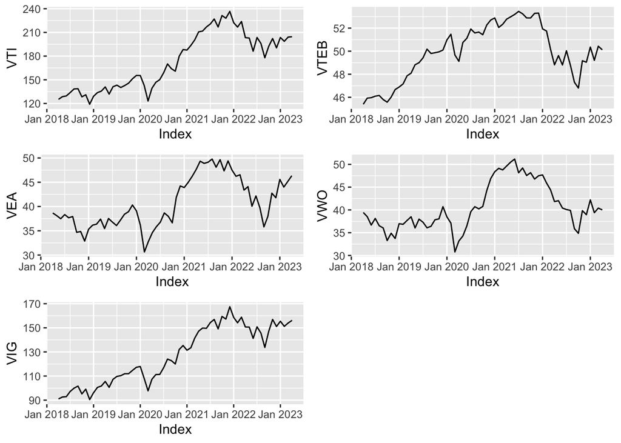

Plot returns:

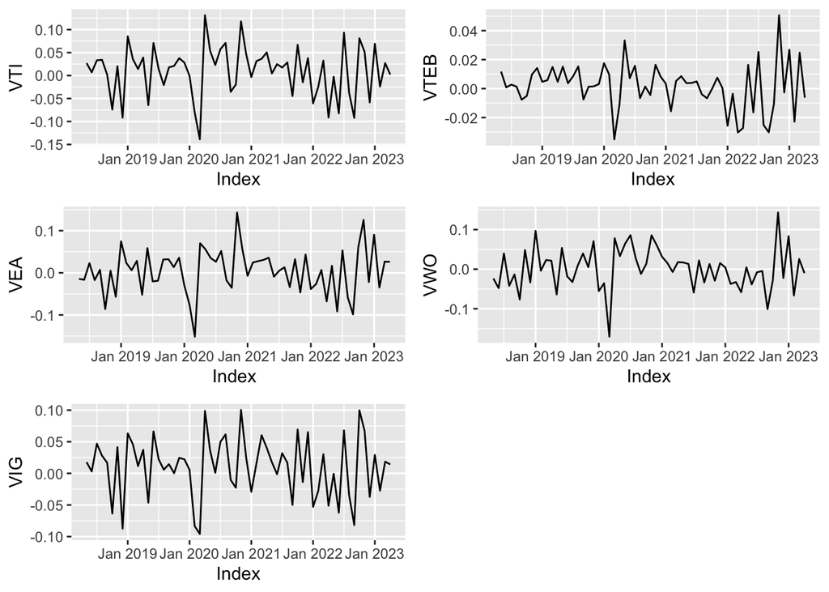

Equity curve

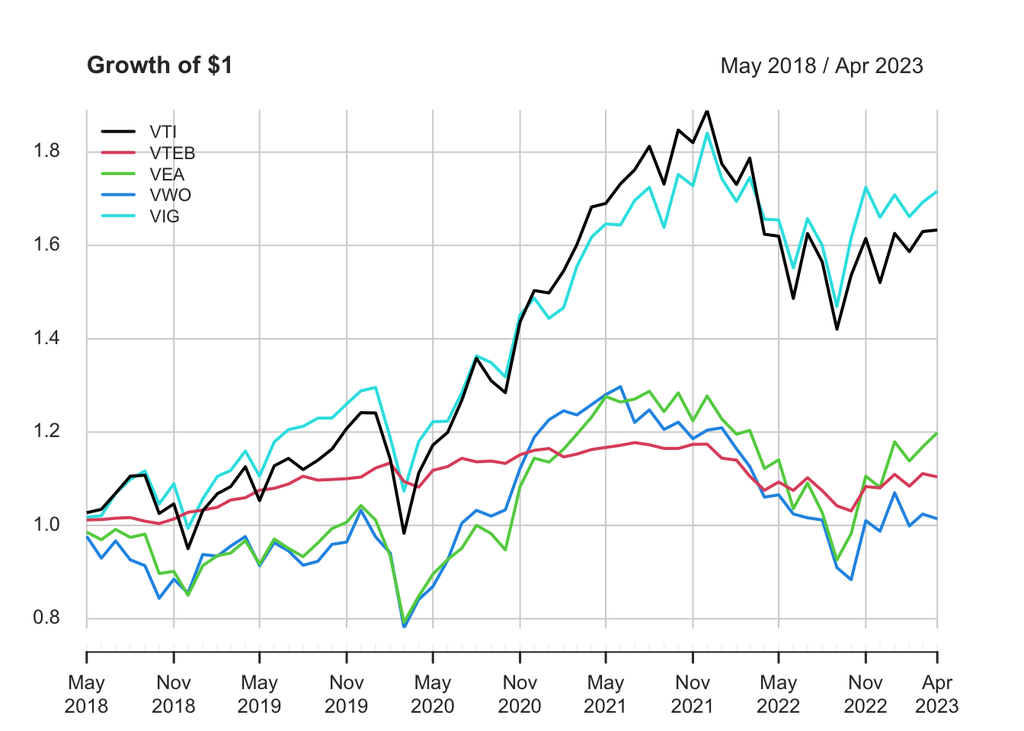

## Sample Statistics

Here is a four panel plot:

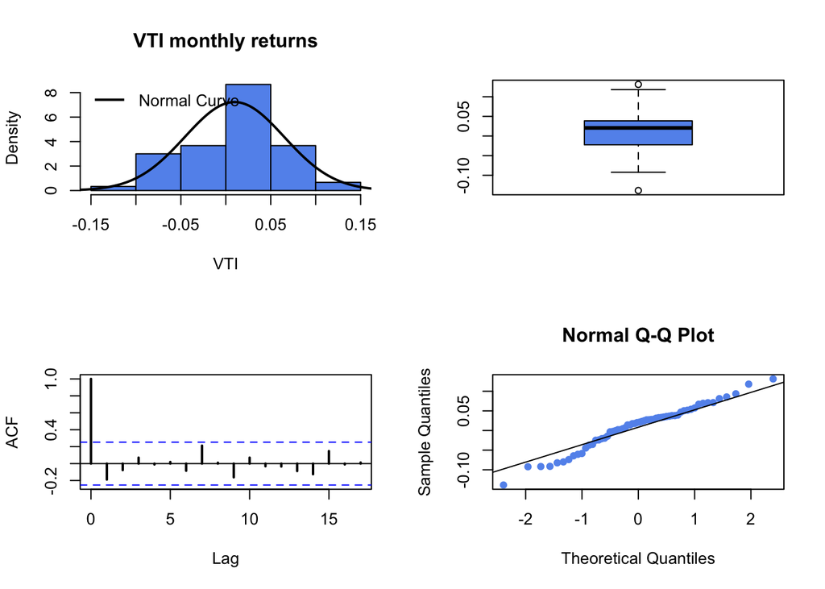

Here is a group boxplot:

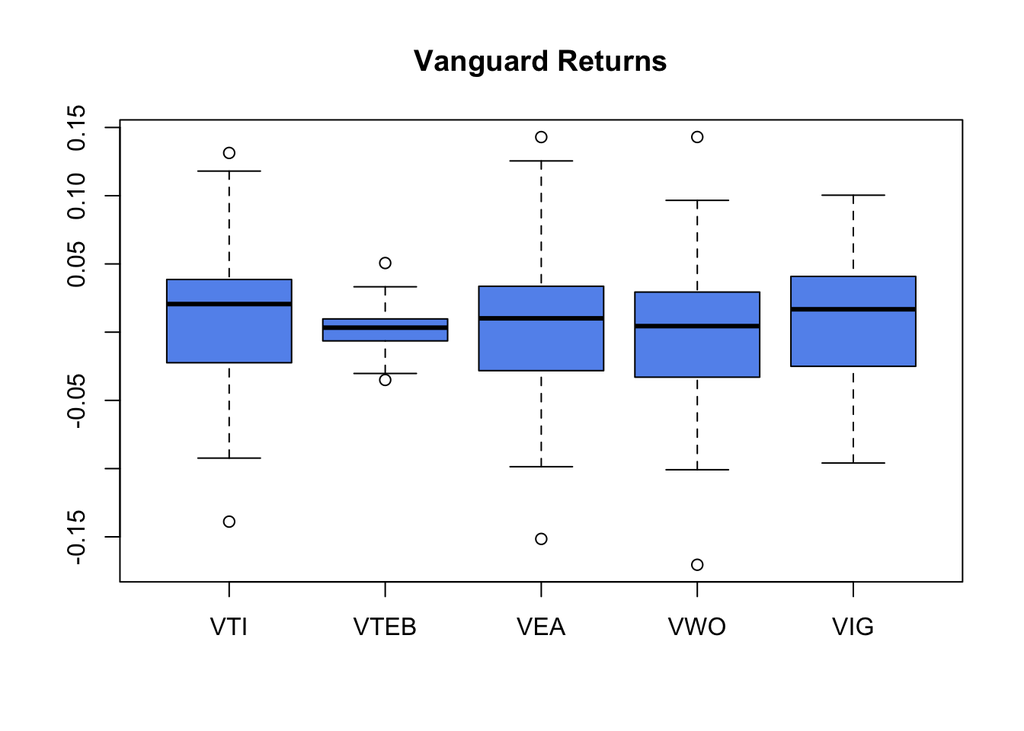

To compute sample statistics you can do this using `apply()` and stats functions or you can use the PerformanceAnalytics function table.Stats():

Brute force:

```
##                      VTI      VTEB      VEA      VWO     VIG
## Mean             0.00972  0.001775  0.00444  0.00162  0.0102
## Std Dev          0.05522  0.015937  0.05335  0.05287  0.0475
## Skewness        -0.42700  0.000035 -0.20135 -0.16008 -0.3240
## Excess Kurtosis  0.01732  0.847784  0.66158  1.09534 -0.3855
## 1% Quantile     -0.11139 -0.032228 -0.12030 -0.12938 -0.0909
## 5% Quantile     -0.09134 -0.027379 -0.08626 -0.06704 -0.0819
```

Or use table.Stats

```r
table.Stats(projectReturns)
```

|  | VTI | VTEB | VEA | VWO | VIG |
| --- | --- | --- | --- | --- | --- |
| Observations | 60.0000 | 60.0000 | 60.0000 | 60.0000 | 60.0000 |
| NAs | 0.0000 | 0.0000 | 0.0000 | 0.0000 | 0.0000 |
| Minimum | -0.1389 | -0.0350 | -0.1515 | -0.1705 | -0.0959 |
| Quartile 1 | -0.0216 | -0.0063 | -0.0274 | -0.0328 | -0.0239 |
| Median | 0.0206 | 0.0033 | 0.0101 | 0.0044 | 0.0168 |
| Arithmetic Mean | 0.0097 | 0.0018 | 0.0044 | 0.0016 | 0.0102 |
| Geometric Mean | 0.0082 | 0.0017 | 0.0030 | 0.0002 | 0.0090 |
| Quartile 3 | 0.0383 | 0.0097 | 0.0330 | 0.0284 | 0.0406 |
| Maximum | 0.1313 | 0.0507 | 0.1430 | 0.1430 | 0.1004 |
| SE Mean | 0.0071 | 0.0021 | 0.0069 | 0.0068 | 0.0061 |

[output cut: 6 more lines]

What is interesting about this table is that the mean return is maximum in VIG and smallest in VWO. I would expect VIG to be the highest return as it is meant to be a growth index fund. The least volatile fund was VTEB, which makes sense as it is the minimum risk fund. THe highest risk is in VTI, which is bad because it does not have the highest return so it seems inefficient.

Risk return plot

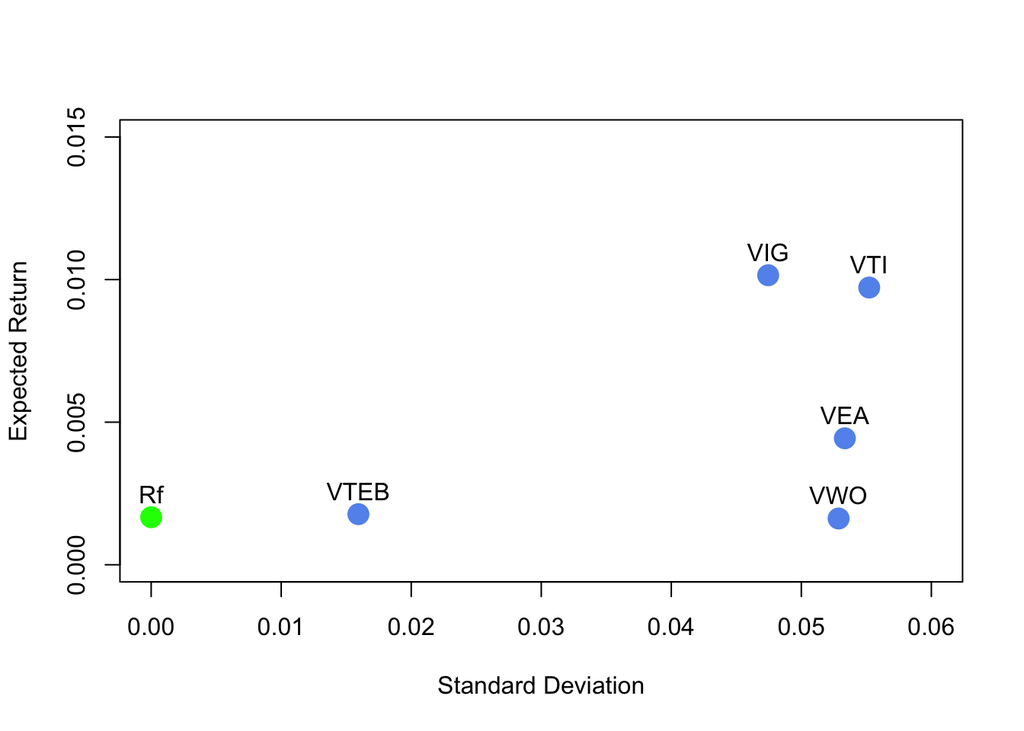

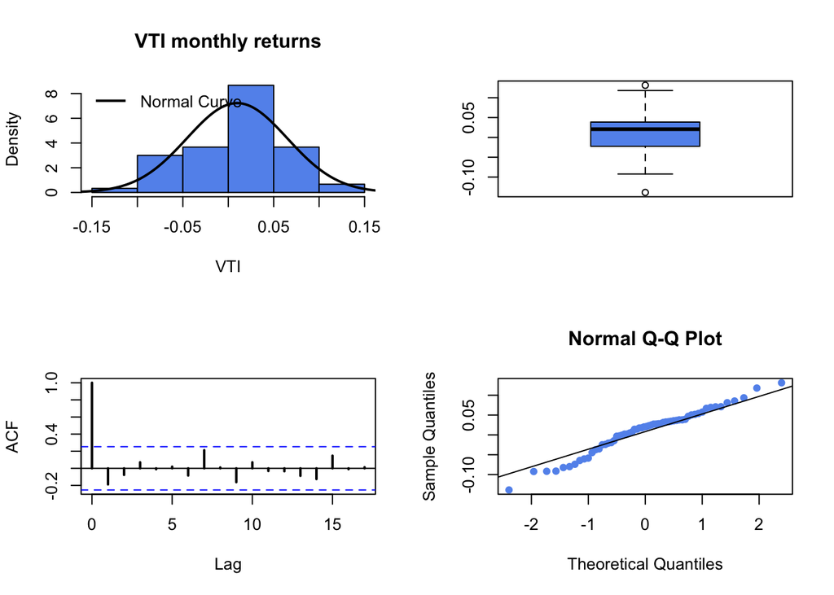

```r
fourPanelPlot(projectReturns[, "VTI", drop=FALSE])
```

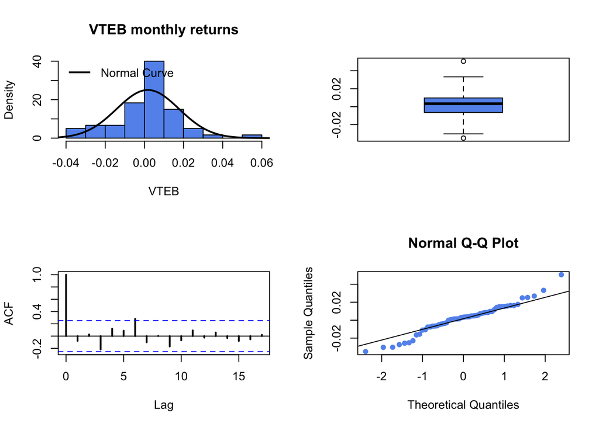

```r
fourPanelPlot(projectReturns[, "VTEB", drop=FALSE])
```

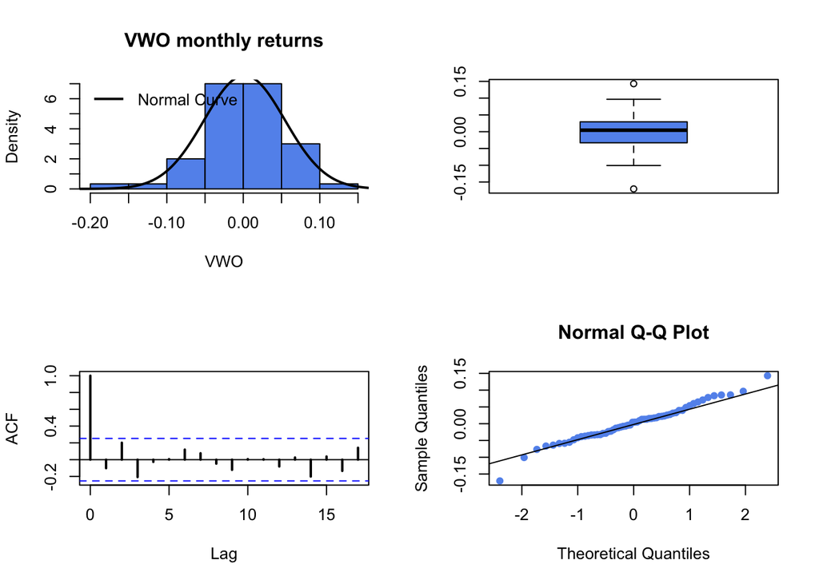

```r
fourPanelPlot(projectReturns[, "VWO", drop=FALSE])
```

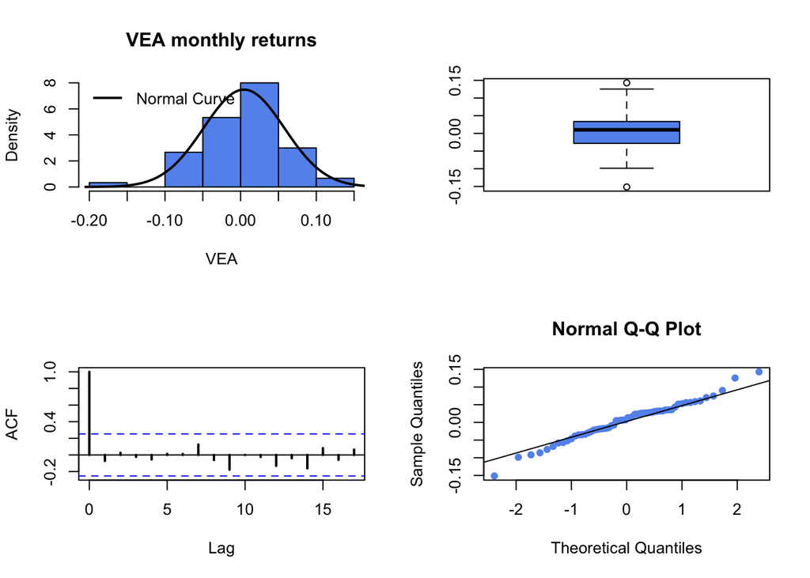

```r
fourPanelPlot(projectReturns[, "VEA", drop=FALSE])
```

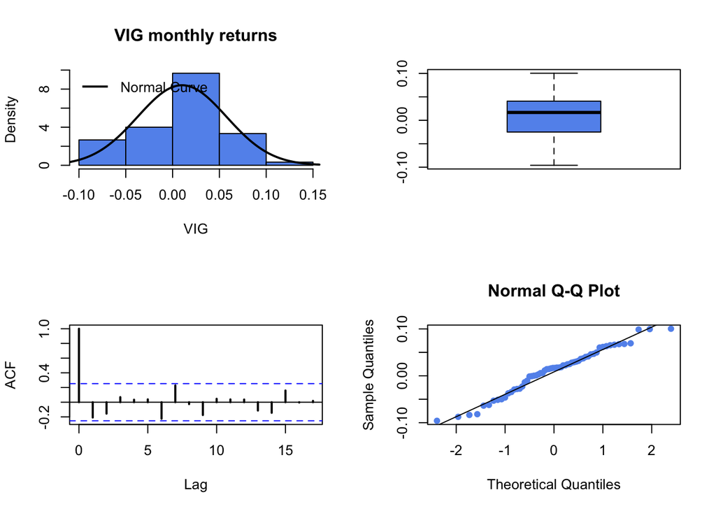

```r
fourPanelPlot(projectReturns[, "VIG", drop=FALSE])
```

The monthly Sharpe ratios are:

```
##           [,1]
## VTI   0.145855
## VTEB  0.006780
## VEA   0.051892
## VWO  -0.000852
## VIG   0.178846
```

Compute pairwise scatterplots

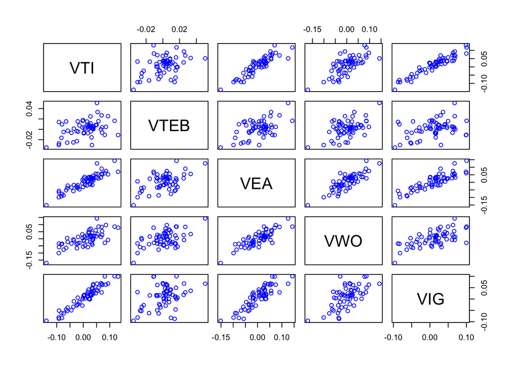

Plot correlations

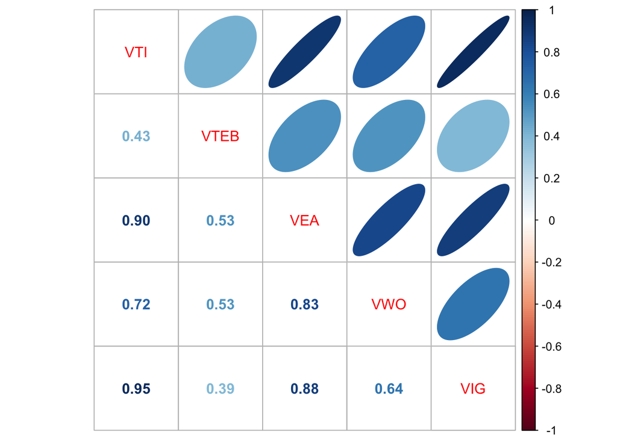